# Network of lawyers: statistical analysis

Davide La Vecchia

Academic year 2026-2027 (Fall semester)

This script is adapted from the book [*Statistical Analysis of Network Data withR*](https://link.springer.com/book/10.1007/978-1-4939-0983-4), by E.D. Kolacyk and G. Csardi. I build on the R code and routines available in the book to illustrate the visualization and the fitting a of ERGMs. I refer to this book for the mathematical details and for additional discussion.

# Overview: Modeling Social Ties

Sociologists have long been interested in understanding what factors influence the development of social ties among actors. Social theory posits many such potential factors. A central tenet of social network analysis is that it is possible to assess the relevance of a given factor(s) on the social dynamics of a population of interest through the statistical modeling and analysis of quantitative measurements of the underlying social network. A well-known example is homophily - the tendency for entities to associate with others like them, popularized in the common parlance through the phrase, “Birds of a feather flock together.” The presence of homophily has been confirmed in numerous social network contexts, often along the lines of the types of characteristics one might expect, such as age, gender, and social class or role.

A common technique for assessing the presence of social factors like homophily in a social network is to construct network regression models, with social ties as response variables $Y$ and measurements relevant to the social factors as predictors $X$.

More precisely, suppose that $\mathcal{G}=(V, E)$ is a graph corresponding to an observed social network among individuals $i \in V$, with a social tie (e.g., friendship) between individuals $i, j \in V$ indicated by an edge $\{i, j\} \in E$. Let $Y_{i j}=Y_{j i}=1$ if $\{i, j\} \in E$, and zero if not. That is,
$$\mathbf{Y}=\left[Y_{i
j}\right]$$
is just the adjacency matrix for $G$, treated as a random matrix.

A regression model for the $Y_{i j}$ ’s might then specify a form for
$$\mathbb{P}\left(Y_{i j}=1 \mid \mathbf{X}_{i}=\mathbf{x}_{i},
\mathbf{X}_{j}=\mathbf{x}_{j}\right),$$
where $\mathbf{X}_{i}$ contains measurements on the $i$-th individual, such as age or gender.

$$\mathbf{Y}_{(-i j)}=\left\{Y_{k l}:\{k, l\} \neq\{i, j\}\right\} .$$
Thus, in building a social network regression model one may want to also include the variables
$$\mathbf{Y}_{(-i j)}$$
as predictors for the $Y_{ij}$ , and specify models for probabilities of the form

$$\mathbb{P}(Y_{ij} =1 \vert \mathbf{Y}_{(-i j)} =\mathbf{y}_{(-i j)},
\mathbf{X}_i =\mathbf{x}_i, \mathbf{X}_j =\mathbf{x}_j).$$
Regression models of this form fall under the class of auto-regression models, in that – unlike standard regression models – the response variable $Y$ also plays a role as a predictor variable. This type of model, analogous to those encountered in time series analysis and the analysis of spatial data, explicitly seeks to capture the type of dependency often inherent in relational data. In addition, such models will potentially have a high number p of parameters, unless simplifications are made (e.g., assumptions of homogeneity of effect sizes across pairs ${i, j}$).

To put these arguments into equations and code them for a real data set, I will work with the `lazega` data set on collaboration among lawyers—see below for details. Within `R` software, I rely on the `ergm` package, which is part of the `statnet` suite of packages. To run the code below you need to load `library(sand)`, `sna`, `network`, and `library(ergm)` as in the lines here below.

```r
#install.packages("sand") # run it if you do not have the package
#install.packages("ergm") # run it if you do not have the package
library(sand)
library(ergm)
data(lazega)
```

# Exploratory data analysis

Here we use only a portion of Lazega’s data set. First, we restrict our attention to only $N_v = 36$ partners in the firm, among whom the administrative structure was said to be ‘relatively decentralized.’ Second, we focus upon the network of collaboration among partners, where an edge is present in our network graph if and only if both partners indicated in a survey that they worked together in a substantive manner. Third, we include data on seniority (i.e., the rank entry of the partner’s entrance into the law firm), gender, office location, and type of practice (i.e., litigation or corporate law).

## Visualize the network by means of a graph

Let us start by a visualization of the network by means of a graph. I display a part of a dataset on collaborative working relationships among members of a New England law firm, collected by Lazega.

These data were collected for the purpose of studying cooperation among social actors in an organization, through the exchange of various types of resources among them. The organization observed was a law firm, consisting of over 70 lawyers (roughly half partners and the other half associates) in three offices located in three different cities. Relational data reflecting resource exchange were collected, and additional attribute information was recorded for each lawyer, including type of practice, gender, and seniority.

```r
colbar <- c("red", "dodgerblue", "goldenrod") # Office location indicated by color.
v.colors <- colbar[V(lazega)$Office] # Type of practice indicated by vertex shape.
```

```
## This graph was created by an old(er) igraph version.
## ℹ Call `igraph::upgrade_graph()` on it to use with the current igraph version.
## For now we convert it on the fly...
```

```r
v.shapes <- c("circle", "square")[V(lazega)$Practice] # Vertex size proportional to years with firm.
v.size <- 3.5*sqrt(V(lazega)$Years) # Label vertices according to seniority.
v.label <- V(lazega)$Seniority
# Reproducible layout.
set.seed(123)
l<- layout.fruchterman.reingold(lazega)
```

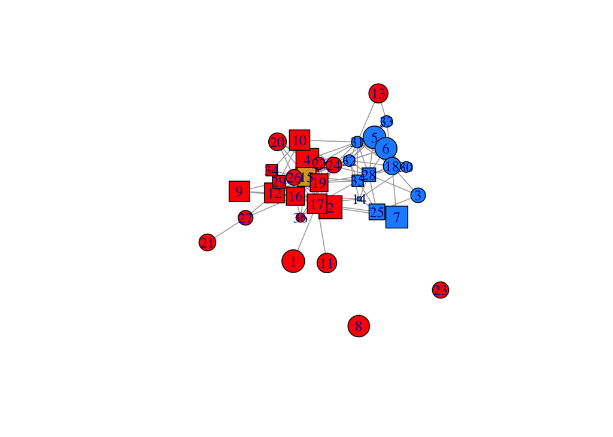

```r
plot(lazega, layout=l,
vertex.color=v.colors, vertex.shape=v.shapes, vertex.size=v.size,
vertex.label=v.label)
```

In this visualization of Lazega’s network of lawyers, vertices represent partners and are labeled according to their seniority (with 1 being most senior). Vertex colors (i.e., red, blue, and yellow) indicate three different office locations, while vertex shape corresponds to the type of practice (i.e., litigation (circle) and corporate (square)). Vertex area is proportional to number of years with the law firm. Edges indicate collaboration between partners. There are three female partners (i.e., those with seniority labels 27, 29, and 34); the rest are male.

# Descriptive statistics

Many questions that might be asked about a vertex in a network graph essentially seek to understand its ‘importance’ in the network. Which actors in the lawyers network seem to hold the ‘reins of power’? To answer this question we need to rely on *measures of centrality*, which are designed to quantify a notion of ‘importance’ and thereby facilitate the answering of such question.

There are a vast number of different centrality measures that have been proposed over the years. Arguably, the most widely used measure of vertex centrality is vertex degree. [Let me remind the notion of the degree of a vertex $v$ which is defined as the number of edges incident on $v$.]. To have an idea of the degree distribution on the lawyers network, I resort on the function `degree`: for details see the [R help](https://www.rdocumentation.org/packages/sna/versions/2.6/topics/degree).

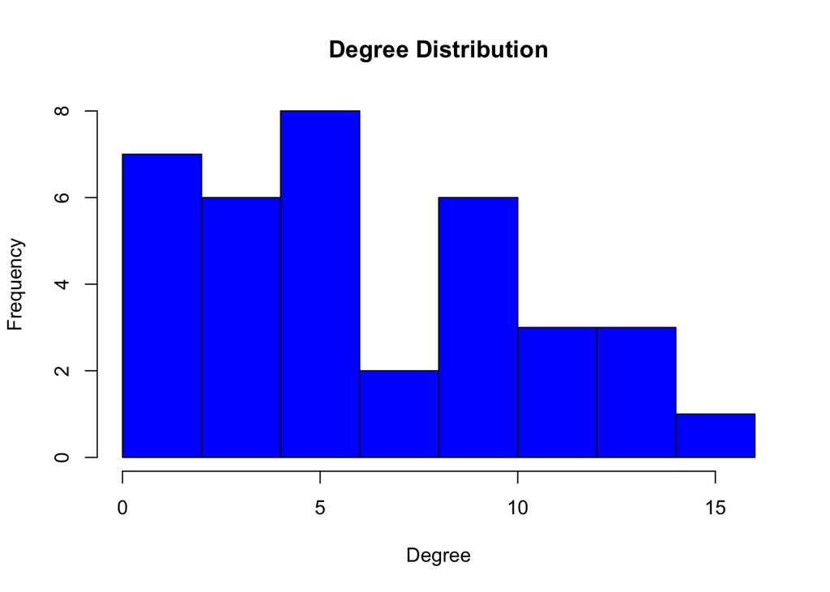

```r
d.lazega <- degree(lazega)
hist(d.lazega,col="blue", xlab="Degree", ylab="Frequency", main="Degree Distribution")
```

Centrality measures attempt to capture the notion that a vertex is ‘central’ if it is ‘close’ to many other vertices. An intuitively appealing way of displaying vertex centralities (for networks of small to moderate size) is to use a radial layout, with more central vertices located closer to the center. The function `gplot.target`, in the package `sna`, can be used for this purpose. For example,

```r
library(sna)
library(network)
A <- get.adjacency(lazega, sparse=FALSE)
g <- network::as.network.matrix(A)
print(degree(g))
```

```
##  [1]  2 12  6 18 12 10  4  0  6 10  2 18  4 12 22 26 30 16 20  8  2 18  0 18 10
## [26] 24  6 26 18  8 26 24 10 12 14  6
```

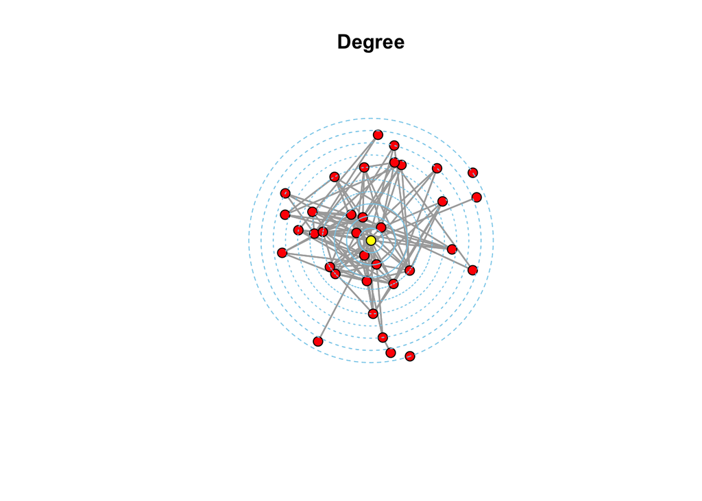

```r
sna::gplot.target(g, degree(g), main="Degree", circ.lab = FALSE, circ.col="skyblue", usearrows = FALSE, vertex.col=c(rep("red", 16), "yellow", rep("red", 16)),  edge.col="darkgray")
```

# Statistical modeling via ERGMs

Exponential random graph models (ERGMs) are designed in direct analogy to the classical generalized linear models (GLMs). They are formulated in a manner that is intended to facilitate the adaptation and extension of well-established statistical principles and methods for the construction, fitting, and comparison of models. Nevertheless, the appropriate specification and fitting of ERGMs can be decidedly more subtle than with standard GLMs.

For the basic ingredients of ERGMs I refer to the set of slides ``Network.pdf’’. Here, we discuss the application of one of these models to the `lazega` dataset, where each $Y_{ij}$ can be either 0 (no edge) or 1 (there is an edge). Therefore, we deal with a Bernoulli random variable, for each pair $(i,j)$, and we study the probabiltiy of links (edges) between the lawyers.

Since `ergm` uses the network package to represent network objects, I need to convert the `igraph` object `lazega` to the format used in `statnet`, first separating the network into adjacency matrix and attributes. This is instrumental to set up the statistical model

$$\begin{equation}
P_\theta(\boldsymbol{Y}=\boldsymbol{y}) =
\frac{1}{\kappa(\theta)} \exp\{\theta L(\boldsymbol{y}) \}
\end{equation}$$
where $L(\boldsymbol{y})= \sum_{i,j} y_{ij}$ and $y_{ij}$ is an edge between vertex $i$ and vertex $j$.

To code in R that model we proceed as follows:

```r
A <- get.adjacency(lazega)
v.attrs <-get.data.frame(lazega, what="vertices")
lazega.s <- network::as.network(as.matrix(A),directed=FALSE)
my.ergm.bern <- formula(lazega.s ~ edges) # set a simple Bernoulli model
```

in which case the statistic $L$ takes the value of the variable `egdes`

```r
summary(my.ergm.bern)
```

```
## edges
##   115
```

The strength of ERGMs lies in the modeler’s ability to specify more sophisticated models than the one discussed above, which relies only on one statistic $L(\boldsymbol{y})$. Doing so properly and effectively, however, requires some thought and care. To begin with, note that the model for $P_\theta(\boldsymbol{Y}=\boldsymbol{y})$ can be thought of as specifying that the log-odds of observing a given network $G$ (or,more specifically, its adjacency matrix $\boldsymbol{y}$) is simply proportional to the number of edges in the network—arguably the most basic of network statistics. Traditionally, it has been of interest to also incorporate analogous statistics of higher-order global network structure, such as counts of $k$-stars, say $S_k(\boldsymbol{y})$, and of triangles, say $T(\boldsymbol{y})$. Frank and Strauss, show that models of the form

$$\begin{equation}
P_\theta(\boldsymbol{Y}=\boldsymbol{y}) =
\frac{1}{\kappa(\theta)} \exp\left\{\sum_{k=1}^{N_{v}-1}\theta_k
S_k(\boldsymbol{y}) + \boldsymbol{\beta}' T(\boldsymbol{y})
\right\},
\end{equation}$$

where $N_v$ is the number of vertices in the graph $G$. In using such models, common practice has been to include star counts $S_k$ no higher than $k=2$,or at most $k=3$,by setting $\theta_4 =···=\theta_{N_{v−1}} =0$. For example, we may fit a more sophisticated model (Markovian which includes edges, $k$-stars, and triangles)

```r
my.ergm.Markov<-formula(lazega.s ~
edges + kstar(2) + kstar(3)+ triangle)
summary(my.ergm.Markov)
```

```
##    edges   kstar2   kstar3 triangle
##      115      926     2681      120
```

While simpler and, ideally, more interpretable, than the general formulation, experience nevertheless has shown this practice to frequently produce models that fit quite poorly to real data. Investigation of this phenomena has found it to be related to the issue of model degeneracy; see book [*Statistical Analysis of Network Data with R*](https://link.springer.com/book/10.1007/978-1-4939-0983-4). Unfortunately, the alternative—including a sufficiently large number of higher order terms—is problematic as well, from the perspective of model fitting. Anyway, let’s go on and set up general statistics that can be used in `ergm` by specifying terms `altkstar, gwdegree, or gwesp,` respectively, in the model. For example,

```r
# or some more statistics
my.ergm.Markov2<-formula(lazega.s ~ edges + gwesp(1, fixed=T))
```

and the statistics take values

```r
summary(my.ergm.Markov2)
```

```
##         edges gwesp.fixed.1
##      115.0000      213.1753
```

Note that all of the model specifications discussed so far involve statistics that are functions only of the network $\boldsymbol{y}$ (i.e., controlling for endogenous effects). Yet it is natural to expect that the chance of an edge joining two vertices depends not only on the status (i.e., presence or absence) of edges between other vertex pairs, but also on attributes of the vertices themselves (i.e., allowing for assessment of exogenous effects). Therefore, it is of interest in a study like this to assess the effects on collaboration of the exogenous attribute variables, while controlling for certain endogenous effects of network structure that might be anticipated, and vice versa. For attributes that have been measured, we can incorporate them into the types of ERGMs we have seen, in the form of additional statistics in the exponential term, with the normalization constant $\kappa(\theta)$ modified analogously.

```r
lazega.s <- network::as.network(as.matrix(A),directed=FALSE)
# attributes specification
network::set.vertex.attribute(lazega.s, "Office",v.attrs$Office)
network::set.vertex.attribute(lazega.s, "Practice",v.attrs$Practice)
network::set.vertex.attribute(lazega.s, "Gender",v.attrs$Gender)
network::set.vertex.attribute(lazega.s, "Seniority", v.attrs$Seniority)
```

In the R package `ergm`, ERGMs are fit using the function `ergm`, which implements a version of Monte Carlo maximum likelihood estimation— namely, an approximate maximum likelihood estimator is returned; the approximation is due to the fact that the computation of the normalizing constant $\kappa(\boldsymbol(\theta))$ is numerically really demanding.

To get the MLE we first set up the model:

```r
lazega.ergm <- formula(lazega.s ~ edges + gwesp(log(3), fixed=TRUE)
+ nodemain("Seniority")
+ nodemain("Practice")
+ match("Practice") + match("Gender") + match("Office"))
```

This specification allows for the control for the density of the network and some effects of transitivity—they are in the term `gwesp(log(3), fixed=TRUE)`. In formula:
$$\begin{equation}
P_\boldsymbol\theta(\boldsymbol{Y}=\boldsymbol{y}) =
\frac{1}{\kappa(\boldsymbol\theta)} \exp\left\{\theta_1
S_1(\boldsymbol{y}) + \theta_2 \text{AT}(\boldsymbol{y}) +
\boldsymbol{\beta}' \tilde g(\boldsymbol{x}) \right\},
\end{equation}$$

where $\boldsymbol\theta=(\theta_1,\theta_2,\boldsymbol\beta)'$ and $\text{AT}(\boldsymbol{y})$ represents a second-order attribute statistic in the model (alternating sum of triangles), controlling for transitivity. **Specifically, for the lawyer data, it is natural to ask to what extent two lawyers that both work with a third lawyer are likely to work with each other as well.** This notion corresponds to the social network concept of transitivity and can be captured numerically through an enumeration of the proportion of vertex triples that form triangles. In addition, it allows us to assess the effect on the formation of collaborative ties among lawyers that is had by seniority, the type of practice (i.e., corporate or litigation), and commonality of practice, gender, and office location (all terms are in $\tilde g$).

```r
set.seed(123)
lazega.ergm.fit <-ergm(lazega.ergm, estimate = "MLE")
```

[output not shown]

[output not shown]

[output not shown]

[output not shown]

[output not shown]

[output not shown]

[output not shown]

[output not shown]

[output not shown]

[output not shown]

[output not shown]

[output not shown]

[output not shown]

```r
summary(lazega.ergm.fit)
```

```
## Call:
## ergm(formula = lazega.ergm, estimate = "MLE")
##
## Monte Carlo Maximum Likelihood Results:
##
##                               Estimate Std. Error MCMC % z value Pr(>|z|)
## edges                        -6.959323   0.707883      0  -9.831  < 1e-04 ***
## gwesp.fixed.1.09861228866811  0.594668   0.088989      0   6.682  < 1e-04 ***
## nodecov.Seniority             0.024325   0.006602      0   3.685 0.000229 ***
## nodecov.Practice              0.386105   0.111157      0   3.474 0.000514 ***
## nodematch.Practice            0.760752   0.192500      0   3.952  < 1e-04 ***
## nodematch.Gender              0.724639   0.251429      0   2.882 0.003951 **
## nodematch.Office              1.158832   0.195171      0   5.938  < 1e-04 ***
## ---
## Signif. codes:  0 '***' 0.001 '**' 0.01 '*' 0.05 '.' 0.1 ' ' 1
##
##      Null Deviance: 873.4  on 630  degrees of freedom
##  Residual Deviance: 459.7  on 623  degrees of freedom
##
## AIC: 473.7  BIC: 504.8  (Smaller is better. MC Std. Err. = 0.3371)
```

**Some comments.** In order to interpret the coefficients, it is useful to think in terms of the probability of a given vertex pair having an edge, conditional on the edge status between all the pairs, the so-called *ceteris paribus analysis*. Writing $\boldsymbol{Y}_{(−ij)}$ to be all of the elements of $\boldsymbol{Y}$ except $Y_{i j}$, the distribution of $Y_{i j}$ conditional on $\boldsymbol{Y}_{(−ij)}$ is Bernoulli and satisfies the expression
$$\ln \left\{\frac{P_\theta(Y_{ij}=1\vert
\boldsymbol{Y}_{(−ij)}= \boldsymbol{y}_{(−ij)})}{P_\theta(Y_{ij}=0\vert
\boldsymbol{Y}_{(−ij)}= \boldsymbol{y}_{(−ij)})}
\right\}=\boldsymbol{\theta}^t \Delta_{ij}(\boldsymbol{y})$$
where $\Delta_{ij}(\boldsymbol{y})$ is the change statistic, denoting the difference between $g(\boldsymbol{y})$ when $y_{ij} =1$ and when $y_{ij} =0$, with $g(\boldsymbol{y})$ being a term of the log likelihood
$$\ell(\theta) = \boldsymbol{\theta}^t g(\boldsymbol{y}) -
\psi(\boldsymbol{\theta}).$$

The estimated coefficient of each attribute statistic in this analysis may be interpreted as a conditional log-odds ratio for cooperation between lawyers. I refer to [*Statistical Analysis of Network Data withR*](https://link.springer.com/book/10.1007/978-1-4939-0983-4), by E.D. Kolacyk and G. Csardi, Ch. 6, section 6.2.3. Here, I provide two examples for the interpretation of the estimated coefficients.

1- Practicing corporate law, rather than litigation, increases the odds of cooperation by a factor of
$$\exp(0.3873) \approx 1.473,$$
or nearly $47.3\%$.

2- Being of the same gender more than doubles the odds of cooperation, since
$$\exp(0.7215) ≈ 2.057.$$
3- In terms of network structure, the magnitude of the coefficient `gwesp` $\approx 0.59$ for the alternating $3$-triangle statistic and the comparatively quite small corresponding standard error indicate that there is strong evidence for a substantial transitivity effect. The quantification of this effect aims to control for basic homophily. So there is likely something other than similarity of gender, practice, and office at work here – possibly additional attributes we have not controlled for, or possibly social processes of team formation.

In all cases, such statements hold in the sense of `all else being equal’ (i.e., given no change among values of the other statistics). Note too that for all of the variables the coefficient differs from zero by at least one standard error, suggesting some nontrivial effect of these variables on the formation of network ties.